# Assignment_FMT_June2020

#### Importing Standard Libraries

```python
import pandas as pd
import numpy as np
import seaborn as sns
import matplotlib.pyplot as plt
%matplotlib inline
import warnings
warnings.filterwarnings("ignore")
```

#### Reading the Data

```python
df = pd.read_csv('concrete.csv')
ori_df = df.copy()
df.head()
```

|  | cement | slag | ash | water | superplastic | coarseagg | fineagg | age | strength |
| --- | --- | --- | --- | --- | --- | --- | --- | --- | --- |
| 0 | 141.3 | 212.0 | 0.0 | 203.5 | 0.0 | 971.8 | 748.5 | 28 | 29.89 |
| 1 | 168.9 | 42.2 | 124.3 | 158.3 | 10.8 | 1080.8 | 796.2 | 14 | 23.51 |
| 2 | 250.0 | 0.0 | 95.7 | 187.4 | 5.5 | 956.9 | 861.2 | 28 | 29.22 |
| 3 | 266.0 | 114.0 | 0.0 | 228.0 | 0.0 | 932.0 | 670.0 | 28 | 45.85 |
| 4 | 154.8 | 183.4 | 0.0 | 193.3 | 9.1 | 1047.4 | 696.7 | 28 | 18.29 |

#### Name of the Variables and Shape of the Data

```python
df.columns
```

```
Index(['cement', 'slag', 'ash', 'water', 'superplastic', 'coarseagg',
       'fineagg', 'age', 'strength'],
      dtype='object')
```

```python
df.shape
```

```
(1030, 9)
```

## Exploratory Data Analysis

```python
df.info()
```

```
<class 'pandas.core.frame.DataFrame'>
RangeIndex: 1030 entries, 0 to 1029
Data columns (total 9 columns):
cement          1030 non-null float64
slag            1030 non-null float64
ash             1030 non-null float64
water           1030 non-null float64
superplastic    1030 non-null float64
coarseagg       1030 non-null float64
fineagg         1030 non-null float64
age             1030 non-null int64
strength        1030 non-null float64
dtypes: float64(8), int64(1)
memory usage: 72.5 KB
```

```python
df.isnull().sum()
```

```
cement          0
slag            0
ash             0
water           0
superplastic    0
coarseagg       0
fineagg         0
age             0
strength        0
dtype: int64
```

##### Observation

- The Dataset consists of 9 variables with 1030 rows
- All the column are Numerical column without any missing values
- The columns slag, ash & superplastic has high number of ZERO values. More then 35% values are ZERO.
- Strength column is the Target variable.

```python
TARGET = "strength"
df.describe().transpose()
```

|  | count | mean | std | min | 25% | 50% | 75% | max |
| --- | --- | --- | --- | --- | --- | --- | --- | --- |
| cement | 1030.0 | 281.167864 | 104.506364 | 102.00 | 192.375 | 272.900 | 350.000 | 540.0 |
| slag | 1030.0 | 73.895825 | 86.279342 | 0.00 | 0.000 | 22.000 | 142.950 | 359.4 |
| ash | 1030.0 | 54.188350 | 63.997004 | 0.00 | 0.000 | 0.000 | 118.300 | 200.1 |
| water | 1030.0 | 181.567282 | 21.354219 | 121.80 | 164.900 | 185.000 | 192.000 | 247.0 |
| superplastic | 1030.0 | 6.204660 | 5.973841 | 0.00 | 0.000 | 6.400 | 10.200 | 32.2 |
| coarseagg | 1030.0 | 972.918932 | 77.753954 | 801.00 | 932.000 | 968.000 | 1029.400 | 1145.0 |
| fineagg | 1030.0 | 773.580485 | 80.175980 | 594.00 | 730.950 | 779.500 | 824.000 | 992.6 |
| age | 1030.0 | 45.662136 | 63.169912 | 1.00 | 7.000 | 28.000 | 56.000 | 365.0 |
| strength | 1030.0 | 35.817961 | 16.705742 | 2.33 | 23.710 | 34.445 | 46.135 | 82.6 |

##### Observations

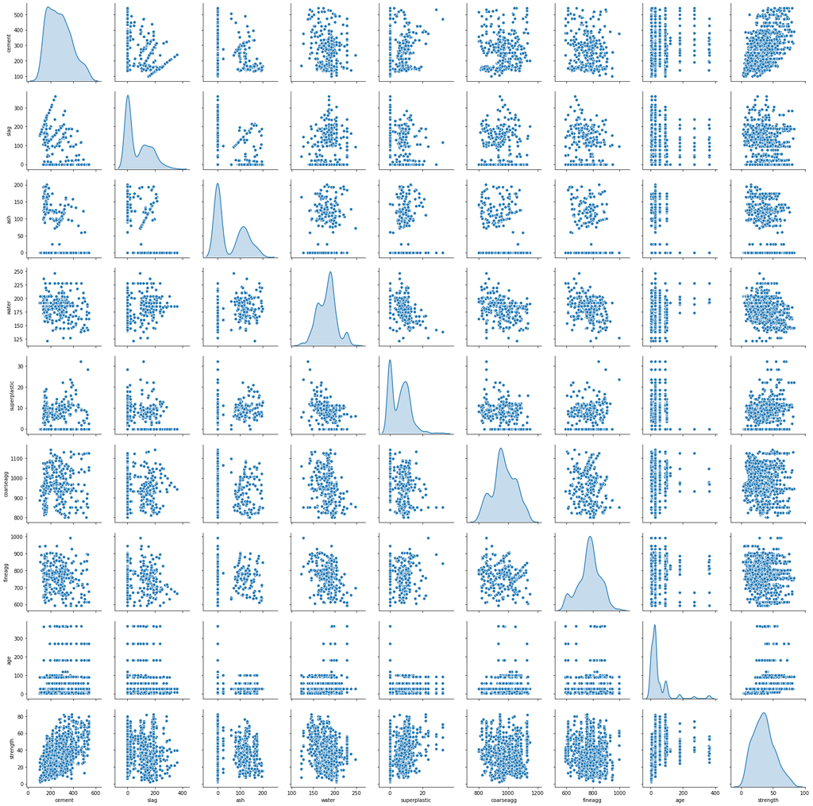

```python
sns.pairplot(df, diag_kind='kde')
```

### Numerical Variables

```python
#Method to show Distribution & Box plot for the variable along with skewness
def showPlots(df, col):
    fig,(ax1,ax2) = plt.subplots(nrows=1,ncols=2)
    fig.set_size_inches(10,2)
    sns.distplot(df[col],ax=ax1)
    ax1.set_title("Distribution Plot")
    sns.boxplot(df[col],ax=ax2)
    ax2.set_title("Box Plot")
    print(df[col].skew())
```

```
0.5094811788717731
```

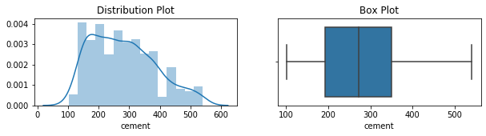

```python
showPlots(df, 'cement')
```

##### Observation: cement column seems normally distributed.

```
0.8007168956061774
```

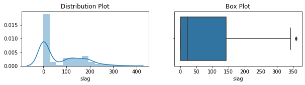

```python
showPlots(df, 'slag')
```

##### Observation: slag column is right skewed with multiple guassian's & presence of outlier

```
0.5373539058066844
```

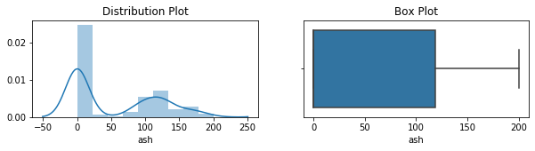

```python
showPlots(df, 'ash')
```

##### Observation: ash column seems normally distributed with multiple guassian's.

```
0.07462838428549402
```

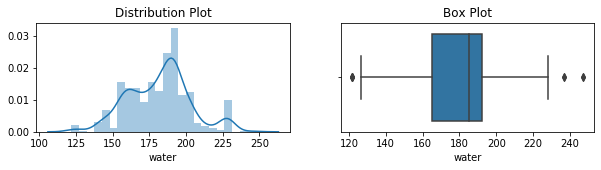

```python
showPlots(df, 'water')
```

##### Observation: water seems normally distributed with multiple guassian's. It also has presence of outliers on both sides.

```
0.9072025748672466
```

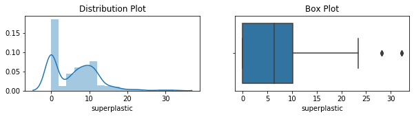

```python
showPlots(df, 'superplastic')
```

##### Observation: superplastic column is right skewed with multiple guassian's & presence of outlier

```
-0.04021974481106704
```

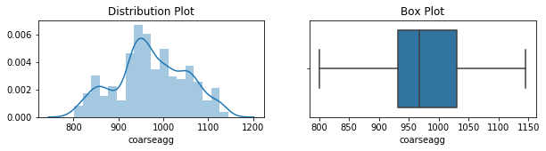

```python
showPlots(df, 'coarseagg')
```

##### Observation: coarseagg seems normally distributed with multiple guassian's.

```
-0.25300959769707143
```

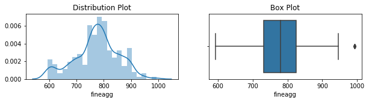

```python
showPlots(df, 'fineagg')
```

##### Observation: fineagg seems normally distributed with multiple guassian's. It also has an outlier.

```
3.2691774006345895
```

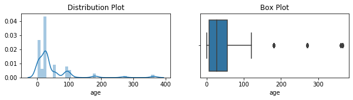

```python
showPlots(df, 'age')
```

##### Observations: age column is right skewed with multiple guassian's & maximum presence of outliers

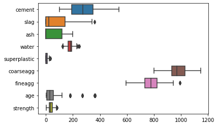

```python
sns.boxplot(data = df, orient='h')
```

#### Summary:

From the above graphs, it can be seen that the columns slag, water, superplastic, fineagg & age has outliers. Therefore, we will treat outliers of these columns before proceeding further.

#### Outliers Treatment

We will replace the outliers with their respective Median value rather then deleting any row OR facing any loss of information

```python
#We will handle the outliers using IQR
from scipy.stats import iqr

def handleOutliers(df, col_name):
    q1 = df[col_name].quantile(0.25)
    q3 = df[col_name].quantile(0.75)
    iqr = q3-q1 #Interquartile range
    fence_low  = q1-1.5*iqr
    fence_high = q3+1.5*iqr
    df[col_name] = np.where(((df[col_name] < fence_low) | (df[col_name] > fence_high)), df[col_name].median(), df[col_name])
    return df[col_name]
```

```python
# Define the columns having outliers & treat them
outliersCols = ["slag", "water", "superplastic", "fineagg", "age"]

for col in outliersCols:
    df[col] = handleOutliers(df, col)
```

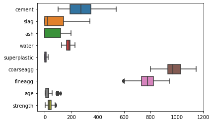

```python
sns.boxplot(data = df, orient='h')
```

#### Target Column Distribution

```
0.41697728841071807
```

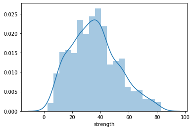

```python
sns.distplot(df[TARGET])
df[TARGET].skew()
```

##### Observation

- The Target column strength seems to be normally distributed.
- Visually a small tail can be noticed on the right side so the variable might be slightly right skewed.

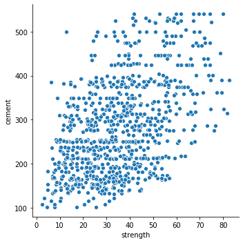

```python
sns.relplot(x=TARGET, y="cement", kind="scatter", data=df)
```

##### Observation: Graph shows some positive linear relation but for a given value of cement we have multiple values of strength. Hence it is a weak predictor even though it has positive linear relationship.

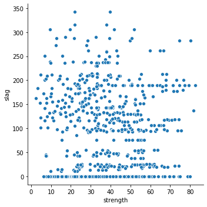

```python
sns.relplot(x=TARGET, y="slag", kind="scatter", data=df)
```

##### Observation: Graph shows Weak relationship with no particular trend.

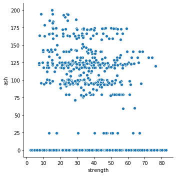

```python
sns.relplot(x=TARGET, y="ash", kind="scatter", data=df);
```

##### Observation: Graph shows Weak relationship with no particular trend.

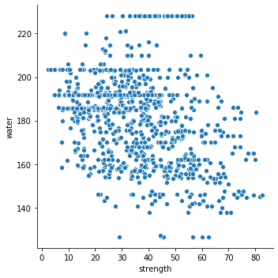

```python
sns.relplot(x=TARGET, y="water", kind="scatter", data=df)
```

##### Observation: Graph shows some negative relationship but it is still a weak predictor.

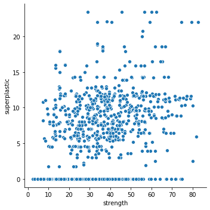

```python
sns.relplot(x=TARGET, y="superplastic", kind="scatter", data=df)
```

##### Observation: Graph shows some positive relationship but it is still a weak predictor.

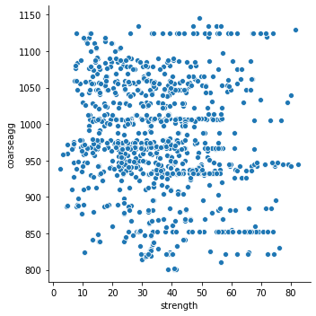

```python
sns.relplot(x=TARGET, y="coarseagg", kind="scatter", data=df)
```

##### Observation: Graph shows Weak relationship with no particular trend.

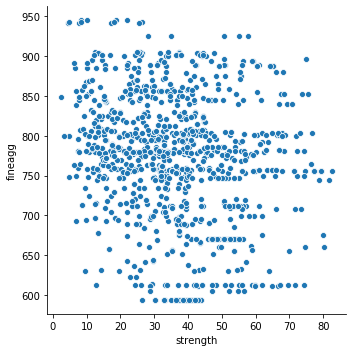

```python
sns.relplot(x=TARGET, y="fineagg", kind="scatter", data=df)
```

##### Observation: Graph shows Weak relationship with no particular trend.

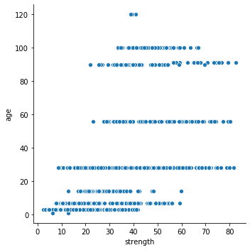

```python
sns.relplot(x=TARGET, y="age", kind="scatter", data=df);
```

##### Observation: Graph shows minute positive linear relation but for a given value of age we have multiple values of strength. Hence it is also a weak predictor

#### Correlation Comparison

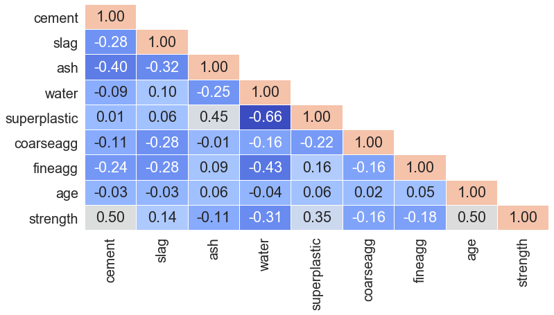

```python
corr = df.corr()
# select only the lower triangle of the correlation matrix
lower_triangle = np.tril(corr)
# to mask the upper triangle in the following heatmap
mask = lower_triangle == 0

plt.figure(figsize = (12,6))
sns.set(font_scale=1.8)
# Setting it to white so that we do not see the grid lines
sns.set_style(style = 'white')
sns.heatmap(lower_triangle, center=0.5, cmap= 'coolwarm', annot= True, xticklabels = corr.index, yticklabels = corr.columns,
            cbar= False, mask = mask, linecolor='white', vmax=.8, fmt='.2f',linewidths=0.01)

#Logic to manage the known issue with Matplotlib version 3.1.11 w.r.t. Heat Map
b, t = plt.ylim() # discover the values for bottom and top
b += 0.5 # Add 0.5 to the bottom
t -= 0.5 # Subtract 0.5 from the top
plt.ylim(b, t) # update the ylim(bottom, top) values
plt.show()
sns.set(font_scale=1)
```

#### Observations:

- cement has moderate positive correlation with strength, moderate negative correlation with ash & low correlation with slag & fineagg.
- slag has low negative correlation with ash, coarseagg & fineagg.
- ash has moderate positive correlation with superplastic & low negative correlation with water.
- water has moderate negative correlation with superplastic & fineagg and low with strength
- superplastic has moderate positive correlation with strength & low negative correlation with coarseagg
- age has moderate postive correlation with strength

#### Summary

- The Pair plot as well as the Correlation Comparison helps us to infer that there ais no significant correlation between any of the atributes. So, we can't drop any column straight away based on correlation results.
- Also, none of the independent attributes individually are a good predictor of the target variable i.e. strength attribute. This indicates there is no linear relationship between the attributes

#### Storing the processed dataset

```python
processed_df = df.copy()
```

### Common Methods

#### Import Libraries

```python
from sklearn.model_selection import train_test_split
from scipy.stats import zscore
from sklearn.preprocessing import StandardScaler
from prettytable import PrettyTable
from sklearn.metrics import mean_squared_error, r2_score
from sklearn import model_selection
from sklearn.preprocessing import PolynomialFeatures
from sklearn.cluster import KMeans

from sklearn.pipeline import make_pipeline
from sklearn.linear_model import LinearRegression, Ridge, Lasso
from sklearn.neighbors import KNeighborsRegressor
from sklearn.tree import DecisionTreeRegressor
from sklearn.svm import SVR
from sklearn.ensemble import RandomForestRegressor, AdaBoostRegressor, GradientBoostingRegressor
from xgboost import XGBRegressor

from sklearn.model_selection import RandomizedSearchCV
```

#### Model Execution Functions

```python
SPLITS = 10
SPLIT_VALUE = 0.30
SEED = 1501
SCORING = 'r2'
MODEL = "Model Name"
TRAIN_SCORE = "Training Score"
TEST_SCORE = "Testing Score"
ACCURACY = "Accuracy/R2 score"
MSE = "Mean Squared Error"
KFOLD = "K Fold Cross Validation"
RANDOM_STATE = 41

# Function to set up results data frame for storing Polynomial feature results
def SetUpPolyResults():
    return pd.DataFrame(columns=[MODEL, TRAIN_SCORE, TEST_SCORE, ACCURACY, MSE])

# Function to set up results data frame for storing Model Building results
def SetUpResults():
    return pd.DataFrame(columns=[MODEL, TRAIN_SCORE, TEST_SCORE, ACCURACY, MSE, KFOLD])

# Function to split Target Variable from data
def SplitData(d):
    #Set of Independent Variables
    X=d.drop(TARGET, axis=1)
    #Dependent Variable
    y=d[TARGET]
    return X,y

# Function to Scale data
def ScaleData(X):
    scaler = StandardScaler()
    return scaler.fit_transform(X)

# Function to split data into training & test set
def SplitTrainTestSet(X, y):
    Xtrain, Xtest, ytrain, ytest = train_test_split (X, y, test_size=SPLIT_VALUE, random_state=SEED)
    #print("Training Data Shape: {0}".format(Xtrain.shape))
    #print("Testing Data Shape: {0}".format(Xtest.shape))
    return Xtrain, Xtest, ytrain, ytest

# Function to Scale data
def PolynomialTransform(X, degree):
    poly = PolynomialFeatures( degree = degree, include_bias = False)
    return poly.fit_transform(X)

# Function to fit the model
def ModelFit (model, Xtr, ytr):
    fit = model.fit(Xtr, ytr)
    #print(fit)
    return model

# Function to predict from model
def ModelPredict (model, Xtt):
    return model.predict(Xtt)

# Function to print the Results of the model
def PrintResults(data):
    x = PrettyTable(list(data.columns))
    for row in data.itertuples():
        x.add_row(row[1:])
    print(str(x))

# Function to perform K-fold Cross Validation on the given model
def KFoldCrossValidation (model, X, y):
    kfold = model_selection.KFold(n_splits=SPLITS)
    results = model_selection.cross_val_score(model, X, y, cv=kfold, scoring = SCORING)
    mean, std = results.mean(), results.std()
    return mean

# Function to get the feature importance & plot the graph
def FeatureImportance(mdl, columns):
    feats = {}
    for feature, importance in zip(columns, mdl.feature_importances_):
        feats[feature] = importance #add the name/value pair
    importances = pd.DataFrame.from_dict(feats, orient='index').rename(columns={0: 'Feature Importance'})
    importances.sort_values(by='Feature Importance').plot(kind='bar', rot=45)
```

#### Polynomial Feature Model Evaluation

```python
# A single Function to execute all the steps for Model Evaluation
def ModelEvaluationPolyFeatures(d, name, model, degree = 0):
    # Splitting Original Data - Extract Target Column
    X, y = SplitData(d)

    # Creating Training & Test Set
    Xtrain, Xtest, ytrain, ytest = SplitTrainTestSet(X, y)

    if degree > 1:
        Xtrain = PolynomialTransform(Xtrain, degree)
        Xtest = PolynomialTransform(Xtest, degree)

    # Model Training/Fitting
    model = ModelFit(model, Xtrain, ytrain)

    # Get Model Prediction & Accuracy Score
    pred = ModelPredict(model, Xtest)

    global results
    results = results.append({
        MODEL: name,
        TRAIN_SCORE: round(model.score(Xtrain, ytrain), 5),
        TEST_SCORE: round(model.score(Xtest, ytest), 5),
        ACCURACY: round(r2_score(ytest, pred), 5),
        MSE: round(mean_squared_error(ytest, pred), 5),
    }, ignore_index=True)
```

## Feature Engineering / Model Building & Evaluation

### Composite Feature / Drop Feature

In the given dataset there are two possible composite feature that we could create & drop the corresponding features from which the composite feature is generated.

1. Water to Cement ratio
2. Water to Binder ratio

##### Water to cement ratio

It is the ratio of the weight of water to the weight of cement used in a concrete mix. A lower ratio leads to higher strength and durability, but may make the mix difficult to work with and form.

```python
df_wc = df.copy()
df_wc.insert(df_wc.shape[-1]-1,'water-cement-ratio', df_wc['water']/df_wc['cement'])
df_wc.drop(['water', 'cement'], axis=1, inplace=True)
df_wc.head()
```

|  | slag | ash | superplastic | coarseagg | fineagg | age | water-cement-ratio | strength |
| --- | --- | --- | --- | --- | --- | --- | --- | --- |
| 0 | 212.0 | 0.0 | 0.0 | 971.8 | 748.5 | 28.0 | 1.440198 | 29.89 |
| 1 | 42.2 | 124.3 | 10.8 | 1080.8 | 796.2 | 14.0 | 0.937241 | 23.51 |
| 2 | 0.0 | 95.7 | 5.5 | 956.9 | 861.2 | 28.0 | 0.749600 | 29.22 |
| 3 | 114.0 | 0.0 | 0.0 | 932.0 | 670.0 | 28.0 | 0.857143 | 45.85 |
| 4 | 183.4 | 0.0 | 9.1 | 1047.4 | 696.7 | 28.0 | 1.248708 | 18.29 |

```python
df_wc.describe().transpose()
```

|  | count | mean | std | min | 25% | 50% | 75% | max |
| --- | --- | --- | --- | --- | --- | --- | --- | --- |
| slag | 1030.0 | 73.240680 | 85.384419 | 0.000000 | 0.000000 | 22.000000 | 142.725000 | 342.100000 |
| ash | 1030.0 | 54.188350 | 63.997004 | 0.000000 | 0.000000 | 0.000000 | 118.300000 | 200.100000 |
| superplastic | 1030.0 | 5.973592 | 5.477165 | 0.000000 | 0.000000 | 6.400000 | 10.075000 | 23.400000 |
| coarseagg | 1030.0 | 972.918932 | 77.753954 | 801.000000 | 932.000000 | 968.000000 | 1029.400000 | 1145.000000 |
| fineagg | 1030.0 | 772.546019 | 78.703232 | 594.000000 | 730.950000 | 779.400000 | 822.200000 | 945.000000 |
| age | 1030.0 | 32.256311 | 27.803705 | 1.000000 | 7.000000 | 28.000000 | 28.000000 | 120.000000 |
| water-cement-ratio | 1030.0 | 0.748865 | 0.312955 | 0.266893 | 0.533333 | 0.675349 | 0.937241 | 1.882353 |
| strength | 1030.0 | 35.817961 | 16.705742 | 2.330000 | 23.710000 | 34.445000 | 46.135000 | 82.600000 |

##### Water to binder ratio

```python
df_wb = df.copy()
df_wb.insert(df_wb.shape[-1]-1,'water-binder-ratio', df_wb['water']/(df_wb['cement'] + df_wb['slag'] + df_wb['ash']))
df_wb.drop(['water', 'cement', 'slag', 'ash'], axis=1, inplace=True)
df_wb.head()
```

|  | superplastic | coarseagg | fineagg | age | water-binder-ratio | strength |
| --- | --- | --- | --- | --- | --- | --- |
| 0 | 0.0 | 971.8 | 748.5 | 28.0 | 0.575998 | 29.89 |
| 1 | 10.8 | 1080.8 | 796.2 | 14.0 | 0.471974 | 23.51 |
| 2 | 5.5 | 956.9 | 861.2 | 28.0 | 0.542089 | 29.22 |
| 3 | 0.0 | 932.0 | 670.0 | 28.0 | 0.600000 | 45.85 |
| 4 | 9.1 | 1047.4 | 696.7 | 28.0 | 0.571555 | 18.29 |

```python
df_wb.describe().transpose()
```

|  | count | mean | std | min | 25% | 50% | 75% | max |
| --- | --- | --- | --- | --- | --- | --- | --- | --- |
| superplastic | 1030.0 | 5.973592 | 5.477165 | 0.000000 | 0.000000 | 6.400000 | 10.075000 | 23.4 |
| coarseagg | 1030.0 | 972.918932 | 77.753954 | 801.000000 | 932.000000 | 968.000000 | 1029.400000 | 1145.0 |
| fineagg | 1030.0 | 772.546019 | 78.703232 | 594.000000 | 730.950000 | 779.400000 | 822.200000 | 945.0 |
| age | 1030.0 | 32.256311 | 27.803705 | 1.000000 | 7.000000 | 28.000000 | 28.000000 | 120.0 |
| water-binder-ratio | 1030.0 | 0.470296 | 0.126784 | 0.235073 | 0.385319 | 0.472032 | 0.561081 | 0.9 |
| strength | 1030.0 | 35.817961 | 16.705742 | 2.330000 | 23.710000 | 34.445000 | 46.135000 | 82.6 |

### Feature Engineering - Polynomial Features

Let us use the simple Linear regression, Ridge & Lasso model to check whether a linear model or a higher degree transform will help.

```python
pipe = make_pipeline(
    StandardScaler(),
    LinearRegression()
)

pipeR = make_pipeline(
    StandardScaler(),
    Ridge(random_state = RANDOM_STATE)
)

pipeL = make_pipeline(
    StandardScaler(),
    Lasso(random_state = RANDOM_STATE)
)
```

```python
df = processed_df.copy()
results = SetUpPolyResults()

# Applying Polynomial Features with degree 2 & 3
for i in range(1,4):
    deg = i
    ModelEvaluationPolyFeatures(df, "Linear Degree = " + str(deg), pipe, deg)
    ModelEvaluationPolyFeatures(df, "Ridge Degree = " + str(deg), pipeR, deg)
    ModelEvaluationPolyFeatures(df, "Lasso Degree = " + str(deg), pipeL, deg)

PrintResults(results)
```

```
+-------------------+----------------+---------------+-------------------+--------------------+
|     Model Name    | Training Score | Testing Score | Accuracy/R2 score | Mean Squared Error |
+-------------------+----------------+---------------+-------------------+--------------------+
| Linear Degree = 1 |    0.71632     |    0.70949    |      0.70949      |      86.41655      |
|  Ridge Degree = 1 |    0.71631     |    0.70915    |      0.70915      |      86.51716      |
|  Lasso Degree = 1 |    0.68877     |    0.67199    |      0.67199      |      97.57205      |
| Linear Degree = 2 |    0.85729     |    0.84599    |      0.84599      |      45.81391      |
|  Ridge Degree = 2 |    0.84879     |    0.84491    |      0.84491      |      46.13505      |
|  Lasso Degree = 2 |    0.70908     |    0.69711    |      0.69711      |      90.10053      |
| Linear Degree = 3 |     0.9396     |    0.88937    |      0.88937      |      32.90894      |
|  Ridge Degree = 3 |    0.89963     |    0.86252    |      0.86252      |      40.89686      |
|  Lasso Degree = 3 |    0.71971     |    0.70289    |      0.70289      |      88.37966      |
+-------------------+----------------+---------------+-------------------+--------------------+
```

##### Observations:

- It was evident from the EDA that there doesn't exists any strong linear relationship of the independent attributes with the target variable hence linear model would not have faired that well.
- The table above shows that the accuracy OR score comes around 70% for all models when we consider the complexity as simple linear i.e. degree = 1
- But, when we move towards quadratic function (degree = 2) and towards cubic function (degree = 3) then we are able to see a sharp increase in the score of Linear Regression & Ridge model. Whereas Lasso fares in a similar way as in a simple linear transform
- For Degree = 2, the rise is of around 14% that comes to more than 84% for both models
- For Degree = 3, the rise is of around 16% that comes to more then 86% for both models. Here, Linear regression performs exceedingly well with almost 89% score as compared to 71% when the complexity was simple linear
- To conclude, quadratic & cubic functions helps to improve the overall performance of the model

### K Means Clustering

In our analysis of the attributes, we were able to see multiple guassians for many attributes. Now, we will use K-Means clustering to group data based on their attribute. First, we need to determine the optimal number of groups by the elbow plot then create appropriate cluster of the given data set

```python
df_km = processed_df.copy()

# Now let us try to scale the variables
from scipy.stats import zscore
scaleddf = df_km.apply(zscore)

cluster_range = range(1,11)
cluster_errors = []
for num_clusters in cluster_range:
    clusters = KMeans(num_clusters, n_init = 5, random_state=SEED)
    clusters.fit(df_km)
    labels = clusters.labels_
    centroids = clusters.cluster_centers_
    cluster_errors.append(clusters.inertia_)

clusters_df = pd.DataFrame({"num_clusters": cluster_range, "cluster_errors": cluster_errors})
clusters_df[0:11]
```

|  | num_clusters | cluster_errors |
| --- | --- | --- |
| 0 | 1 | 3.709976e+07 |
| 1 | 2 | 2.774842e+07 |
| 2 | 3 | 2.145656e+07 |
| 3 | 4 | 1.870758e+07 |
| 4 | 5 | 1.659663e+07 |
| 5 | 6 | 1.500261e+07 |
| 6 | 7 | 1.375955e+07 |
| 7 | 8 | 1.239091e+07 |
| 8 | 9 | 1.126072e+07 |
| 9 | 10 | 1.052231e+07 |

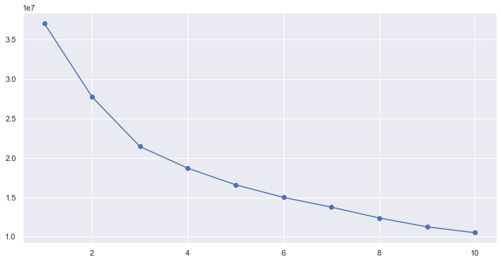

```python
from matplotlib import cm

plt.figure(figsize=(12,6))
plt.plot(clusters_df.num_clusters, clusters_df.cluster_errors, marker = "o" )
```

##### Observation: The bend in the elbow plot seems to coming 4 or 5. Let us evaluate which is the better one.

```python
from sklearn.metrics import silhouette_score
# For k=4
k = KMeans(n_clusters = 4, n_init = 5, random_state=SEED)
k.fit(scaleddf)
labels = k.labels_
print(silhouette_score(scaleddf, labels))

# For k=5
k1 = KMeans(n_clusters = 5, n_init = 5, random_state=SEED)
k1.fit(scaleddf)
labels1 = k1.labels_
print(silhouette_score(scaleddf, labels1))
```

```
0.219815269970415
0.20945876749211984
```

##### Observation: The Silhouette score shows k=4 is better then k=5. We will proceed with k=4

```python
centroids = k.cluster_centers_
centroid_df = pd.DataFrame(centroids, columns = list(df_km) )
centroid_df
```

|  | cement | slag | ash | water | superplastic | coarseagg | fineagg | age | strength |
| --- | --- | --- | --- | --- | --- | --- | --- | --- | --- |
| 0 | 0.744459 | -0.780535 | -0.792902 | 0.666877 | -1.039472 | 0.456328 | -0.228575 | -0.116009 | -0.243063 |
| 1 | -0.578570 | -0.589050 | 1.127410 | -0.397353 | 0.513304 | 0.276263 | 0.376935 | 0.160659 | -0.215556 |
| 2 | 1.007993 | 0.454943 | -0.416338 | -0.969783 | 1.017167 | -0.687410 | 0.132936 | 0.060073 | 1.165480 |
| 3 | -0.789007 | 1.227063 | -0.409795 | 0.676581 | -0.498777 | -0.274413 | -0.399272 | -0.154191 | -0.421099 |

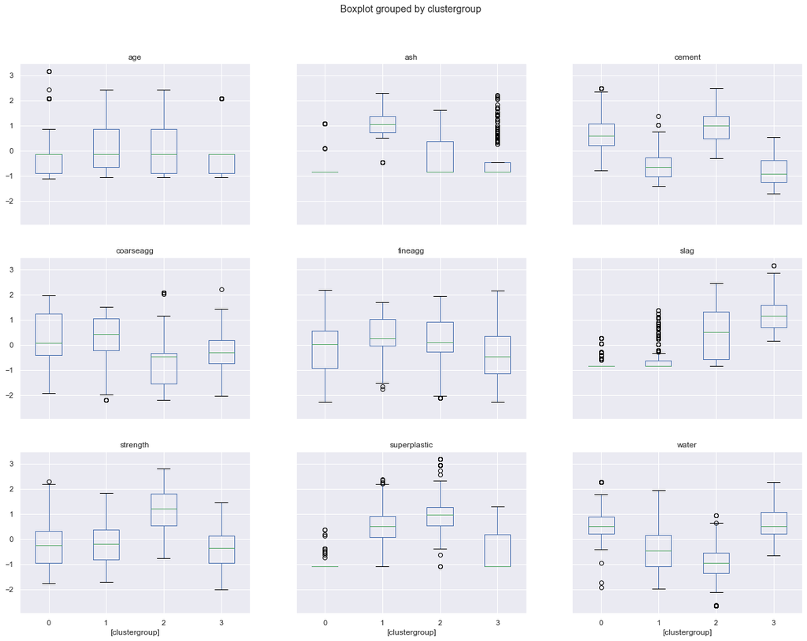

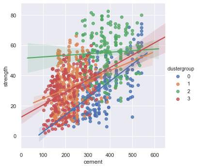

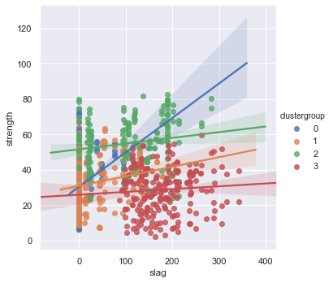

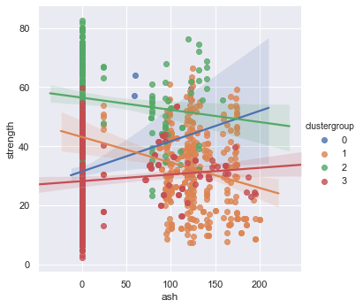

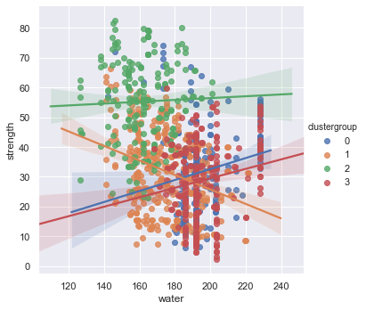

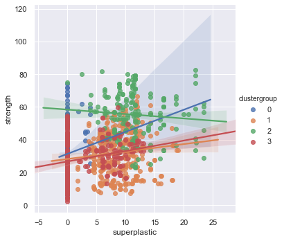

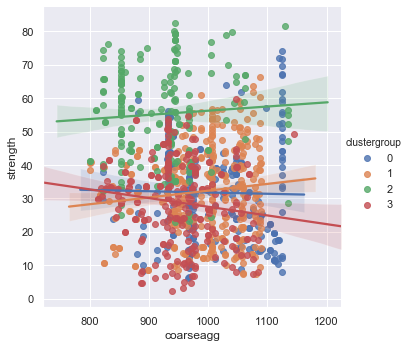

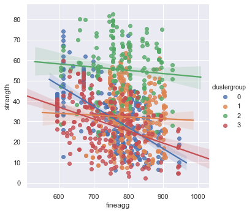

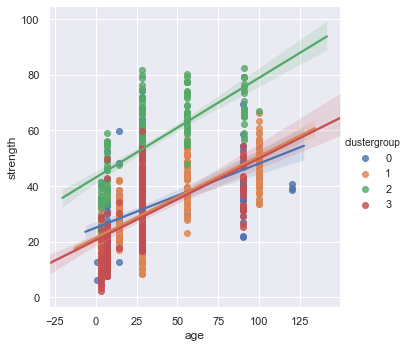

```python
prediction=k.predict(scaleddf)
scaleddf["clustergroup"] = prediction
scaleddf.boxplot(by='clustergroup', layout=(3,3), figsize=(20, 15))

df_km.insert(df_km.shape[1]-1, 'clustergroup', prediction)
for col in df_km.columns[:-2]:
  sns.lmplot(data=df_km, x=col, y='strength', hue='clustergroup')
```

## Model Building

#### Model Evaluation Function

```python
# A single Function to execute all the steps for Model Evaluation
def ModelEvaluation(d, name, model, tuning = 0, feature = 0):
    # Splitting Original Data - Extract Target Column
    X, y = SplitData(d)

    # Creating Training & Test Set
    Xtrain, Xtest, ytrain, ytest = SplitTrainTestSet(X, y)

    # Standardize X Data
    Xtrain = ScaleData(Xtrain)
    Xtest = ScaleData(Xtest)

    # Model Training/Fitting
    model = ModelFit(model, Xtrain, ytrain) if tuning == 0 else model(Xtrain, ytrain)

    # Feature Importance of the model
    if feature == 1 :
        FeatureImportance(model, d.columns)

    # Get Model Prediction & Accuracy Score
    pred = ModelPredict(model, Xtest)

    # Perform Cross Validation
    mean = KFoldCrossValidation(model, X, y)

    global results
    results = results.append({
        MODEL: name,
        TRAIN_SCORE: round(model.score(Xtrain, ytrain), 5),
        TEST_SCORE: round(model.score(Xtest, ytest), 5),
        ACCURACY: round(r2_score(ytest, pred), 5),
        MSE: round(mean_squared_error(ytest, pred), 5),
        KFOLD: round(mean, 5)
    }, ignore_index=True)
```

```python
# Function to evaluate different regressors based on the data supplied
def EvaluateRegressors(data):
    global results
    results = SetUpResults()
    ModelEvaluation(data, 'Decision Tree', DecisionTreeRegressor(random_state = RANDOM_STATE))
    ModelEvaluation(data, 'Random Forest', RandomForestRegressor(random_state = RANDOM_STATE))
    ModelEvaluation(data, 'Ada Boosting', AdaBoostRegressor(random_state = RANDOM_STATE))
    ModelEvaluation(data, 'Gradient Boosting', GradientBoostingRegressor(random_state = RANDOM_STATE))
    ModelEvaluation(data, 'XG Boost', XGBRegressor(objective ='reg:squarederror'))
    ModelEvaluation(data, 'K Neighbors', KNeighborsRegressor())
    ModelEvaluation(data, 'SVR', SVR())
    PrintResults(results)
```

#### Evaluate regressors on the original dataset

```python
EvaluateRegressors(df)
```

```
+-------------------+----------------+---------------+-------------------+--------------------+-------------------------+
|     Model Name    | Training Score | Testing Score | Accuracy/R2 score | Mean Squared Error | K Fold Cross Validation |
+-------------------+----------------+---------------+-------------------+--------------------+-------------------------+
|   Decision Tree   |    0.99475     |    0.76998    |      0.76998      |      68.42352      |         0.86022         |
|   Random Forest   |    0.97324     |    0.86695    |      0.86695      |      39.57686      |         0.89341         |
|    Ada Boosting   |    0.82244     |    0.74974    |      0.74974      |      74.44531      |         0.77356         |
| Gradient Boosting |    0.94496     |    0.86185    |      0.86185      |      41.09407      |         0.89924         |
|      XG Boost     |    0.94114     |    0.86063    |      0.86063      |      41.45908      |         0.89658         |
|    K Neighbors    |    0.85943     |    0.79198    |      0.79198      |      61.87961      |         0.68895         |
|        SVR        |     0.7161     |    0.69666    |      0.69666      |      90.2336       |         0.01466         |
+-------------------+----------------+---------------+-------------------+--------------------+-------------------------+
```

##### Observations:

- Out of all the models (regressors) the following models have performed very well in order of highest to lowest accuracy on the original dataset
  - Random Forest
  - Gradient Boosting
  - XG Boost
- Other models haven't performed that well with SVR having the lowest score

#### Evaluate regressors on dataset after creating composite feature of water to binder ratio

```python
EvaluateRegressors(df_wb)
```

```
+-------------------+----------------+---------------+-------------------+--------------------+-------------------------+
|     Model Name    | Training Score | Testing Score | Accuracy/R2 score | Mean Squared Error | K Fold Cross Validation |
+-------------------+----------------+---------------+-------------------+--------------------+-------------------------+
|   Decision Tree   |    0.99238     |    0.76803    |      0.76803      |      69.00396      |         0.84189         |
|   Random Forest   |    0.96866     |    0.84527    |      0.84527      |      46.02697      |         0.88833         |
|    Ada Boosting   |     0.8116     |    0.78388    |      0.78388      |      64.28966      |         0.78077         |
| Gradient Boosting |    0.91786     |    0.86058    |      0.86058      |      41.47348      |         0.87563         |
|      XG Boost     |    0.91486     |    0.85219    |      0.85219      |      43.96934      |         0.87136         |
|    K Neighbors    |    0.86584     |    0.77805    |      0.77805      |      66.0226       |         0.51984         |
|        SVR        |    0.68794     |    0.67715    |      0.67715      |      96.03693      |         0.05491         |
+-------------------+----------------+---------------+-------------------+--------------------+-------------------------+
```

##### Observations:

- Out of all the models (regressors) the following models have performed very well in order of highest to lowest accuracy on dataset after creating composite feature of water to binder ratio
  - Gradient Boosting
  - XG Boost
  - Random Forest
- Other models haven't performed that well with SVR having the lowest score